# Исследование и анализ данных интернет-магазина

**Цель проекта** – определение закономерностей, влияющих на успешность игр для планирования рекламных кампаний

**Задачи проекта**:

- обработка входных данных;
- исследовательский анализ: поиск зависимостей и расчет показателей в разрезе жанров, объема продаж, регионов и пр.;
- составление портрета пользователя каждого региона;
- проверка гипотез.

**Входные данные** — на входе были получены данные из открытых источников до 2016 г., 1 файл _.csv (информация содержит данные о продажах компьютерных игр, оценки пользователей и экспертов, жанрах и платформах). За 2016 г. могут быть неполные данные.

В процессе работы над проектом будут реализованы следующие **шаги:**

1. загрузка и знакомство с данными
2. предобработка данных
   - поиск и обработка пропусков и дубликатов
   - изменение типов данных и названий столбцов при необходимости
   - группировка данныз, расчет суммарных показателей
3. исследовательский анализ данных - определение соотношений, распределений
   - данных о выпуске игр, о продажах по разным годам,
   - данных о жанрах игр,
   - выбор актуального периода для формирования прогнозов,
   - определение влияния отзывов пользователей и критиков на продажи.
4. составление портрета пользователя каждого региона
5. проверка гипотез о соответствии рейтингов.

```python
import pandas as pd

import matplotlib.pyplot as plt

import numpy as np

import seaborn as sns

from scipy import stats as st

import warnings
```

### Загрузка данных

```python
#загружаем данные

data = pd.read_csv('games.csv')
```

```python
#посмотрим как выглядит таблица

data.head(10)
```

|  | Name | Platform | Year_of_Release | Genre | NA_sales | EU_sales | JP_sales | Other_sales | Critic_Score | User_Score | Rating |
| --- | --- | --- | --- | --- | --- | --- | --- | --- | --- | --- | --- |
| 0 | Wii Sports | Wii | 2006.0 | Sports | 41.36 | 28.96 | 3.77 | 8.45 | 76.0 | 8 | E |
| 1 | Super Mario Bros. | NES | 1985.0 | Platform | 29.08 | 3.58 | 6.81 | 0.77 | NaN | NaN | NaN |
| 2 | Mario Kart Wii | Wii | 2008.0 | Racing | 15.68 | 12.76 | 3.79 | 3.29 | 82.0 | 8.3 | E |
| 3 | Wii Sports Resort | Wii | 2009.0 | Sports | 15.61 | 10.93 | 3.28 | 2.95 | 80.0 | 8 | E |
| 4 | Pokemon Red/Pokemon Blue | GB | 1996.0 | Role-Playing | 11.27 | 8.89 | 10.22 | 1.00 | NaN | NaN | NaN |
| 5 | Tetris | GB | 1989.0 | Puzzle | 23.20 | 2.26 | 4.22 | 0.58 | NaN | NaN | NaN |
| 6 | New Super Mario Bros. | DS | 2006.0 | Platform | 11.28 | 9.14 | 6.50 | 2.88 | 89.0 | 8.5 | E |
| 7 | Wii Play | Wii | 2006.0 | Misc | 13.96 | 9.18 | 2.93 | 2.84 | 58.0 | 6.6 | E |
| 8 | New Super Mario Bros. Wii | Wii | 2009.0 | Platform | 14.44 | 6.94 | 4.70 | 2.24 | 87.0 | 8.4 | E |
| 9 | Duck Hunt | NES | 1984.0 | Shooter | 26.93 | 0.63 | 0.28 | 0.47 | NaN | NaN | NaN |

Из таблицы видно, что наименование столбцов требует изменений, представлены разные типы данных, их нужно проверить, в столбцах есть пропуски, которые также нужно будет отработать.

```python
# ознакомимся с общей информацией

data.info()
```

```
<class 'pandas.core.frame.DataFrame'>
RangeIndex: 16715 entries, 0 to 16714
Data columns (total 11 columns):
 #   Column           Non-Null Count  Dtype
---  ------           --------------  -----
 0   Name             16713 non-null  object
 1   Platform         16715 non-null  object
 2   Year_of_Release  16446 non-null  float64
 3   Genre            16713 non-null  object
 4   NA_sales         16715 non-null  float64
 5   EU_sales         16715 non-null  float64
 6   JP_sales         16715 non-null  float64
 7   Other_sales      16715 non-null  float64
 8   Critic_Score     8137 non-null   float64
 9   User_Score       10014 non-null  object
 10  Rating           9949 non-null   object
dtypes: float64(6), object(5)
memory usage: 1.4+ MB
```

Нулевые значения присутствуют в 6 из 11 столбцов, тип данных указан неверно в столбцах `User_Score`и `Year_of_Release`.

**Вывод по разделу 1.1**

Данные загружены, сформирована общая информация о них.

При первом приближении отметим, что наименование столбцов понятно, верно описывает представленные данные в соотетствующем столбце, указаны на одном языке, но регистр требует изменений. Представлены разные типы данных, в двух столбцах требуется изменение. Присутствуют незаполненные ячейки в данных.

### Предобработка данных

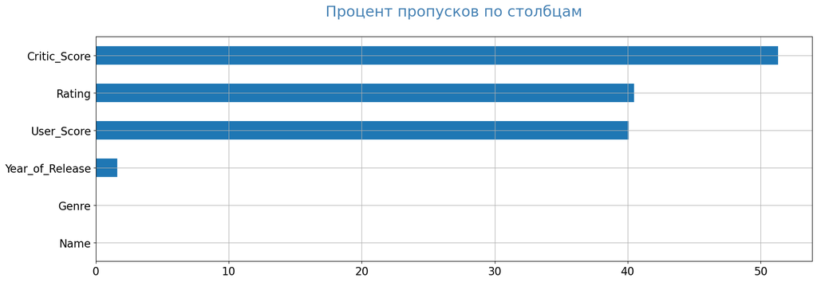

```python
# пропущенные значения

def pass_value_barh(df):
    try:
        (
            (df.isna().mean()*100)
            .to_frame()
            .rename(columns = {0:'space'})
            .query('space > 0')
            .sort_values(by = 'space', ascending = True)
            .plot(kind = 'barh', figsize = (19,6), legend = False, fontsize = 16,grid=True)
            .set_title('Процент пропусков по столбцам' + "\n", fontsize = 22, color = 'SteelBlue')
        );
    except:
        print('пропусков не осталось :) или произошла ошибка в первой части функции ')

pass_value_barh(data)
```

#### Изменение наименований столбцов

Приведем все названия столбцов к нижнему регистру.

```python
data.columns = data.columns.str.lower()

# проверим

data.columns
```

```
Index(['name', 'platform', 'year_of_release', 'genre', 'na_sales', 'eu_sales',
       'jp_sales', 'other_sales', 'critic_score', 'user_score', 'rating'],
      dtype='object')
```

#### Изменение типов данных

Еще раз сформируем информацию о данных.

```python
data.info()
```

```
<class 'pandas.core.frame.DataFrame'>
RangeIndex: 16715 entries, 0 to 16714
Data columns (total 11 columns):
 #   Column           Non-Null Count  Dtype
---  ------           --------------  -----
 0   name             16713 non-null  object
 1   platform         16715 non-null  object
 2   year_of_release  16446 non-null  float64
 3   genre            16713 non-null  object
 4   na_sales         16715 non-null  float64
 5   eu_sales         16715 non-null  float64
 6   jp_sales         16715 non-null  float64
 7   other_sales      16715 non-null  float64
 8   critic_score     8137 non-null   float64
 9   user_score       10014 non-null  object
 10  rating           9949 non-null   object
dtypes: float64(6), object(5)
memory usage: 1.4+ MB
```

Во-первых, можно поменять тип данных на 'int' в солбце `year_of_release`, но так как в столбце есть пропуски, мы не можем это сделать, к тому же тип 'float64' не помешает анализу, поэтому оставим без изменений.

Что касается столбца `user_score`, то здесь требуется изменение на 'float'. В нем есть какие-то еще типы данных кроме пропусков, потому что указан тип object.

```python
#посмотрим какие значения есть в данном столбце

data['user_score'].unique()
```

```
array(['8', nan, '8.3', '8.5', '6.6', '8.4', '8.6', '7.7', '6.3', '7.4',
       '8.2', '9', '7.9', '8.1', '8.7', '7.1', '3.4', '5.3', '4.8', '3.2',
       '8.9', '6.4', '7.8', '7.5', '2.6', '7.2', '9.2', '7', '7.3', '4.3',
       '7.6', '5.7', '5', '9.1', '6.5', 'tbd', '8.8', '6.9', '9.4', '6.8',
       '6.1', '6.7', '5.4', '4', '4.9', '4.5', '9.3', '6.2', '4.2', '6',
       '3.7', '4.1', '5.8', '5.6', '5.5', '4.4', '4.6', '5.9', '3.9',
       '3.1', '2.9', '5.2', '3.3', '4.7', '5.1', '3.5', '2.5', '1.9', '3',
       '2.7', '2.2', '2', '9.5', '2.1', '3.6', '2.8', '1.8', '3.8', '0',
       '1.6', '9.6', '2.4', '1.7', '1.1', '0.3', '1.5', '0.7', '1.2',
       '2.3', '0.5', '1.3', '0.2', '0.6', '1.4', '0.9', '1', '9.7'],
      dtype=object)
```

Аббревиатура `tbd` означает 'To Be Determined', то есть будет определено, но пока нет, поэтому это тоже самое, что пропуски. Заменим эти значения также на пропуски, чтобы преобразовать тип данных в столбце.

```python
data['user_score'] = data['user_score'].replace('tbd', np.nan)

data['user_score'] = data['user_score'].astype(float)

data.info()
```

```
<class 'pandas.core.frame.DataFrame'>
RangeIndex: 16715 entries, 0 to 16714
Data columns (total 11 columns):
 #   Column           Non-Null Count  Dtype
---  ------           --------------  -----
 0   name             16713 non-null  object
 1   platform         16715 non-null  object
 2   year_of_release  16446 non-null  float64
 3   genre            16713 non-null  object
 4   na_sales         16715 non-null  float64
 5   eu_sales         16715 non-null  float64
 6   jp_sales         16715 non-null  float64
 7   other_sales      16715 non-null  float64
 8   critic_score     8137 non-null   float64
 9   user_score       7590 non-null   float64
 10  rating           9949 non-null   object
dtypes: float64(7), object(4)
memory usage: 1.4+ MB
```

Теперь с типами данных все в порядке.

#### Обработка пропусков

Выведем информацию о пропусках по столбцам и обработаем их по возможности

```python
data.isna().sum()
```

```
name                  2
platform              0
year_of_release     269
genre                 2
na_sales              0
eu_sales              0
jp_sales              0
other_sales           0
critic_score       8578
user_score         9125
rating             6766
dtype: int64
```

```python
data[data['name'].isna()]
```

|  | name | platform | year_of_release | genre | na_sales | eu_sales | jp_sales | other_sales | critic_score | user_score | rating |
| --- | --- | --- | --- | --- | --- | --- | --- | --- | --- | --- | --- |
| 659 | NaN | GEN | 1993.0 | NaN | 1.78 | 0.53 | 0.00 | 0.08 | NaN | NaN | NaN |
| 14244 | NaN | GEN | 1993.0 | NaN | 0.00 | 0.00 | 0.03 | 0.00 | NaN | NaN | NaN |

В этих двух строках отсутсnвует информация практически по всем столбцам. Имеет смысл удалить эти строки, так как их всего 2.

```python
data = data.dropna(subset=['name'])

data.isna().sum()
```

```
name                  0
platform              0
year_of_release     269
genre                 0
na_sales              0
eu_sales              0
jp_sales              0
other_sales           0
critic_score       8576
user_score         9123
rating             6764
dtype: int64
```

Что касается столбцов `critic_score`, `user_score`, `rating`, пропуски в них могут быть связаны со старыми годами релиза, когда не были еще так популярны рейтинги, а также с небольшим объемом продаж и в принципе отсутствием оценок пользователей и критиков данных игр.

Рейтинг ESRB (столбец `rating`) не является юридически обязательным, однако крупные магазины обращают на это внимание и могут отказаться от продажи без соответсвующего знака на упаковке. Из этого можно сделать вывод, что скорее всего пропуски в играх непопулярных с небольшими продажами.

В столбцах `critic_score`, `user_score` мы не будем заменять пропуски, так как средние или медианные значения могут исказить общую картину, а в столбце `rating` (так как он имеет тип данных object) заменим на no_rating.

```python
data['rating'] = data['rating'].fillna('no_rating')

data.isna().sum()
```

```
name                  0
platform              0
year_of_release     269
genre                 0
na_sales              0
eu_sales              0
jp_sales              0
other_sales           0
critic_score       8576
user_score         9123
rating                0
dtype: int64
```

Что касается года релиза, то количество строк с пропусками составляет 269 или 2% от общей базы. Так как далее мы будем проводить аналитику преимущественно по годам, то наиболее правильным будет также удалить эти строки.

```python
data = data.dropna(subset=['year_of_release'])

data.isna().sum()
```

```
name                  0
platform              0
year_of_release       0
genre                 0
na_sales              0
eu_sales              0
jp_sales              0
other_sales           0
critic_score       8461
user_score         8981
rating                0
dtype: int64
```

```python
data.shape
```

```
(16444, 11)
```

Пропуски максимально отработаны.

#### Проверка на дубликаты

Также посмотрим полные дубликаты, а также неявные и проверим возможные наименования в столбцах с типом object.

```python
#zявные дубликаты

data.duplicated().sum()
```

```
0
```

Приведем значения категориальных столбцов `name`,`platform`,`genre`к нижнему регистру

```python
data['name'] = data['name'].str.lower()

data['platform'] = data['platform'].str.lower()

data['genre'] = data['genre'].str.lower()
```

Проверим дубликаты по ключевым столбцам.

```python
data.duplicated(subset=['name', 'platform', 'year_of_release']).sum()
```

```
1
```

```python
#посмотрим, что это за строка

data[data.duplicated(subset=['name', 'platform', 'year_of_release'])]
```

|  | name | platform | year_of_release | genre | na_sales | eu_sales | jp_sales | other_sales | critic_score | user_score | rating |
| --- | --- | --- | --- | --- | --- | --- | --- | --- | --- | --- | --- |
| 16230 | madden nfl 13 | ps3 | 2012.0 | sports | 0.0 | 0.01 | 0.0 | 0.0 | 83.0 | 5.5 | E |

```python
data.query('name=="madden nfl 13" and platform=="ps3"')
```

|  | name | platform | year_of_release | genre | na_sales | eu_sales | jp_sales | other_sales | critic_score | user_score | rating |
| --- | --- | --- | --- | --- | --- | --- | --- | --- | --- | --- | --- |
| 604 | madden nfl 13 | ps3 | 2012.0 | sports | 2.11 | 0.22 | 0.0 | 0.23 | 83.0 | 5.5 | E |
| 16230 | madden nfl 13 | ps3 | 2012.0 | sports | 0.00 | 0.01 | 0.0 | 0.00 | 83.0 | 5.5 | E |

Мы видим, что строки идентичны, только в одной из них есть дополнительные продажи по региону. Объединим эти строки.

```python
data.at[604, 'eu_sales'] = 0.23

data.query('name=="madden nfl 13" and platform=="ps3"')
```

|  | name | platform | year_of_release | genre | na_sales | eu_sales | jp_sales | other_sales | critic_score | user_score | rating |
| --- | --- | --- | --- | --- | --- | --- | --- | --- | --- | --- | --- |
| 604 | madden nfl 13 | ps3 | 2012.0 | sports | 2.11 | 0.23 | 0.0 | 0.23 | 83.0 | 5.5 | E |
| 16230 | madden nfl 13 | ps3 | 2012.0 | sports | 0.00 | 0.01 | 0.0 | 0.00 | 83.0 | 5.5 | E |

```python
#теперь удалим дубликат

data = data.drop(16230)

data.shape
```

```
(16443, 11)
```

Неявные дубликаты, которые нас интересуют, могут быть в столбцах `platform`,`genre`. А также проверим правильно ли указаны знаки в `rating`.

```python
data['platform'].sort_values().unique()
```

```
array(['2600', '3do', '3ds', 'dc', 'ds', 'gb', 'gba', 'gc', 'gen', 'gg',
       'n64', 'nes', 'ng', 'pc', 'pcfx', 'ps', 'ps2', 'ps3', 'ps4', 'psp',
       'psv', 'sat', 'scd', 'snes', 'tg16', 'wii', 'wiiu', 'ws', 'x360',
       'xb', 'xone'], dtype=object)
```

```python
data['genre'].sort_values().unique()
```

```
array(['action', 'adventure', 'fighting', 'misc', 'platform', 'puzzle',
       'racing', 'role-playing', 'shooter', 'simulation', 'sports',
       'strategy'], dtype=object)
```

Неявных дубликатов не обнаружено.

```python
#gпроверим категории рейтинга ESRB

data['rating'].sort_values().unique()
```

```
array(['AO', 'E', 'E10+', 'EC', 'K-A', 'M', 'RP', 'T', 'no_rating'],
      dtype=object)
```

Рейтинг К-А действовал до 1998 г., далее был переименован в Е, так что можем его заменить.

```python
data.query('rating == "K-A"') #подтвердим, что год до 1998
```

|  | name | platform | year_of_release | genre | na_sales | eu_sales | jp_sales | other_sales | critic_score | user_score | rating |
| --- | --- | --- | --- | --- | --- | --- | --- | --- | --- | --- | --- |
| 656 | theme hospital | pc | 1997.0 | strategy | 2.30 | 0.10 | 0.00 | 0.00 | NaN | 9.0 | K-A |
| 903 | parappa the rapper | ps | 1996.0 | misc | 0.26 | 0.16 | 1.46 | 0.03 | 92.0 | 7.4 | K-A |
| 16681 | worms 2 | pc | 1997.0 | strategy | 0.00 | 0.01 | 0.00 | 0.00 | NaN | 8.1 | K-A |

```python
data['rating'] = data['rating'].replace('K-A','E')

data['rating'].sort_values().unique()
```

```
array(['AO', 'E', 'E10+', 'EC', 'M', 'RP', 'T', 'no_rating'], dtype=object)
```

Также посмотрим за какие года представлены данные.

```python
data['year_of_release'].sort_values().unique()
```

```
array([1980., 1981., 1982., 1983., 1984., 1985., 1986., 1987., 1988.,
       1989., 1990., 1991., 1992., 1993., 1994., 1995., 1996., 1997.,
       1998., 1999., 2000., 2001., 2002., 2003., 2004., 2005., 2006.,
       2007., 2008., 2009., 2010., 2011., 2012., 2013., 2014., 2015.,
       2016.])
```

#### Суммарные продажи

Добавим новый столбец с общей суммой всех продаж по регионам по играм.

```python
data['total_sales'] = data[['na_sales','eu_sales','jp_sales', 'other_sales']].sum(axis = 1)

data.head()
```

|  | name | platform | year_of_release | genre | na_sales | eu_sales | jp_sales | other_sales | critic_score | user_score | rating | total_sales |
| --- | --- | --- | --- | --- | --- | --- | --- | --- | --- | --- | --- | --- |
| 0 | wii sports | wii | 2006.0 | sports | 41.36 | 28.96 | 3.77 | 8.45 | 76.0 | 8.0 | E | 82.54 |
| 1 | super mario bros. | nes | 1985.0 | platform | 29.08 | 3.58 | 6.81 | 0.77 | NaN | NaN | no_rating | 40.24 |
| 2 | mario kart wii | wii | 2008.0 | racing | 15.68 | 12.76 | 3.79 | 3.29 | 82.0 | 8.3 | E | 35.52 |
| 3 | wii sports resort | wii | 2009.0 | sports | 15.61 | 10.93 | 3.28 | 2.95 | 80.0 | 8.0 | E | 32.77 |
| 4 | pokemon red/pokemon blue | gb | 1996.0 | role-playing | 11.27 | 8.89 | 10.22 | 1.00 | NaN | NaN | no_rating | 31.38 |

**Вывод по разделу 1.2**

Данные в таблице обработаны:

- наименования столбцов и значения в категориальных колонках приведены к нижнему регистру;
- изменен тип данных в столбце `user_score` на float;
- обработаны пропуски:
  - удалены строки с пустыми ячейками в столбцах `year_of_release`,`genre`. В этих строках отсутствовала ключевая информация для дальнейшего исследования, кроме этого количество удаленных строк составило только 1,6%;
  - пропуски в оценках критиков и пользователей оставлены без изменений, чтобы не исказить общую картину;
  - пропуски в `rating` заменены на no_rating;
- полных дубликатов нет, неполные дубликаты устранены;
- неявные дубликаты выявлены только в столбце `rating`, были заменены;
- добавлен дополнительный столбец `total_sales` , в котором рассчитана общая сумма продаж по всем регионам;
- в таблице представлены данные за период 1980 - 2016 гг.

### Исследовательский анализ данных

#### Количество игр по годам

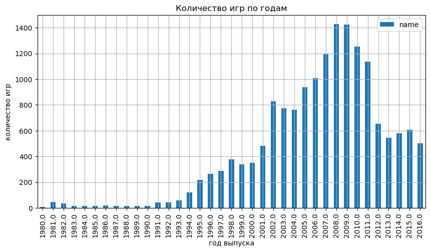

```python
data.pivot_table(index='year_of_release',values='name',aggfunc='count').plot.bar(figsize=(10,5),grid=True)

plt.title('Количество игр по годам')

plt.xlabel('год выпуска')
plt.ylabel('количество игр')

plt.show()
```

Из графика видно, что пик выпуска игр приходится на 2008-2009 гг. Также можно отметить, что до 1994 г. количество выпуска игр крайне мало, далее начинается рост, с 2009 г. количество выпускаемых игр снижается, что связано с падением спроса.

#### Платформы с наибольшими суммарными продажами. Распределение по годам

Выберем топ-5 платформ с наибольшими суммарными продажами.

```python
data.pivot_table(index='platform',values='total_sales',aggfunc='sum').sort_values(
    by='total_sales', ascending=False).head()
```

| platform | total_sales |
| --- | --- |
| ps2 | 1233.56 |
| x360 | 961.24 |
| ps3 | 931.34 |
| wii | 891.18 |
| ds | 802.78 |

Построим распределение по годам по данным платформам.

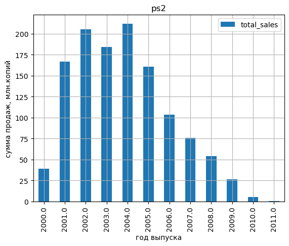

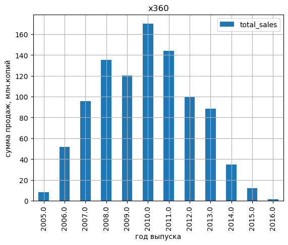

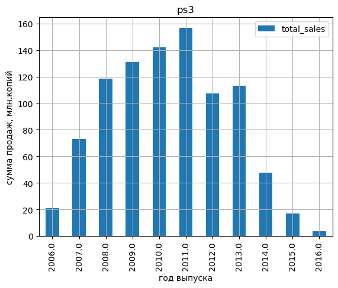

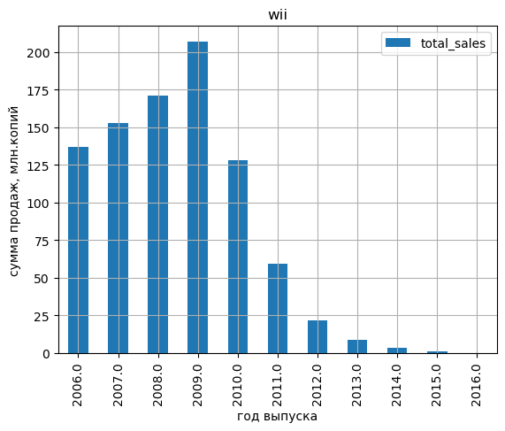

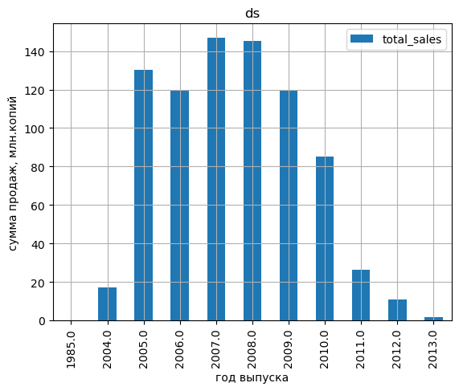

```python
top5=['ps2', 'x360','ps3' ,'wii' ,'ds']

for i in top5:
    data.query('platform == @i').pivot_table(
    index='year_of_release',values='total_sales',aggfunc='sum').plot.bar(grid=True, title=i)

    plt.xlabel('год выпуска')
    plt.ylabel('сумма продаж, млн.копий')

plt.show()
```

Из графиков видно, что средний срок жизни платформы - 10 лет, самые популярные платформы появлялись в начале 2000-х, за исключением ds, которая, судя по графику, появилась в 1985 г., однако на самом деле эта платформа появилась только в 2004 г. Поэтому стоит удалить эту аномалию.

```python
#посмотрим сколько таких строк и какие данные мы теряем

data.query('platform=="ds" and year_of_release==1985.0')
```

|  | name | platform | year_of_release | genre | na_sales | eu_sales | jp_sales | other_sales | critic_score | user_score | rating | total_sales |
| --- | --- | --- | --- | --- | --- | --- | --- | --- | --- | --- | --- | --- |
| 15957 | strongest tokyo university shogi ds | ds | 1985.0 | action | 0.0 | 0.0 | 0.02 | 0.0 | NaN | NaN | no_rating | 0.02 |

```python
#также посмотрим, что в базе больше нет строк с такой игрой

data.query('name=="strongest tokyo university shogi ds"')
```

|  | name | platform | year_of_release | genre | na_sales | eu_sales | jp_sales | other_sales | critic_score | user_score | rating | total_sales |
| --- | --- | --- | --- | --- | --- | --- | --- | --- | --- | --- | --- | --- |
| 15957 | strongest tokyo university shogi ds | ds | 1985.0 | action | 0.0 | 0.0 | 0.02 | 0.0 | NaN | NaN | no_rating | 0.02 |

```python
# удалим эту строку из базы

data = data.query('name!="strongest tokyo university shogi ds"')

data.shape #должна уйти 1 строка
```

```
(16442, 12)
```

#### Определение актуального периода для дальнейших исследований.

На первый взгдяж кажется, что необходимо взять самые пиковые периоды, однако это слишком длительный период для прогноза продаж по платформам.

Во-первых, мы увидели, что в принципе рынок упал и с 2013 г. устанавливается новый более низкий уровень по продажам.

Во-вторых, мы определили, что платформы "живут" в среднем 10 лет, то есть то, что было популярно в 2003-2005 гг. к сегодняшнему дню не актуально или вообще этих платформ нет на рынке и появились новые версии.

Таким образом, разумно будет взять период с 2013 г. по 2016 г. Мы увидим лидеров в новой реальности рынка, а также, если платформа находится на подъеме (а пик обычно середина 10-летия жизни), то в следующем прогнозном году продажи будут выше, а если уже наступает снижение, то, попадая в лидеры, мы понимаем, что около 2 лет вокруг нашего года эта платформа также будет еще популярна.

Прежде чем откидывать данные, посмотрим верна ли теория.

```python
data.query('year_of_release>=2013.0').pivot_table(
    index=['platform','year_of_release'],values='total_sales',aggfunc='sum').sort_values(
    by=['platform','year_of_release'], ascending=False).reset_index()
```

|  | platform | year_of_release | total_sales |
| --- | --- | --- | --- |
| 0 | xone | 2016.0 | 26.15 |
| 1 | xone | 2015.0 | 60.14 |
| 2 | xone | 2014.0 | 54.07 |
| 3 | xone | 2013.0 | 18.96 |
| 4 | x360 | 2016.0 | 1.52 |
| 5 | x360 | 2015.0 | 11.96 |
| 6 | x360 | 2014.0 | 34.74 |
| 7 | x360 | 2013.0 | 88.58 |
| 8 | wiiu | 2016.0 | 4.60 |
| 9 | wiiu | 2015.0 | 16.35 |
| 10 | wiiu | 2014.0 | 22.03 |
| 11 | wiiu | 2013.0 | 21.65 |
| 12 | wii | 2016.0 | 0.18 |
| 13 | wii | 2015.0 | 1.14 |
| 14 | wii | 2014.0 | 3.75 |
| 15 | wii | 2013.0 | 8.59 |
| 16 | psv | 2016.0 | 4.25 |
| 17 | psv | 2015.0 | 6.25 |
| 18 | psv | 2014.0 | 11.90 |
| 19 | psv | 2013.0 | 10.59 |
| 20 | psp | 2015.0 | 0.12 |
| 21 | psp | 2014.0 | 0.24 |
| 22 | psp | 2013.0 | 3.14 |
| 23 | ps4 | 2016.0 | 69.25 |
| 24 | ps4 | 2015.0 | 118.90 |
| 25 | ps4 | 2014.0 | 100.00 |
| 26 | ps4 | 2013.0 | 25.99 |
| 27 | ps3 | 2016.0 | 3.60 |
| 28 | ps3 | 2015.0 | 16.82 |
| 29 | ps3 | 2014.0 | 47.76 |
| 30 | ps3 | 2013.0 | 113.25 |
| 31 | pc | 2016.0 | 5.25 |
| 32 | pc | 2015.0 | 8.52 |
| 33 | pc | 2014.0 | 13.28 |
| 34 | pc | 2013.0 | 12.38 |
| 35 | ds | 2013.0 | 1.54 |
| 36 | 3ds | 2016.0 | 15.14 |
| 37 | 3ds | 2015.0 | 27.78 |
| 38 | 3ds | 2014.0 | 43.76 |
| 39 | 3ds | 2013.0 | 56.57 |

Данные показывают, что действительно одни платформы начинают расти в то время как другие теряют продажи.

Так, например, X360 уступил место новой версии XOne, а PS4 пришел на смену PS3.

Но здесь можно отметить еще одну особенность - в 2016 г. даже если продажи росли до этого по всем этим платформам наблюдается падение, причем довольно резкое. Это может быть связано, скорее всего, с тем, что за 2016 г. представлены неполные данные. Но исключать этот год не будем, но будем иметь ввиду, что скорее всего падение связано с непоными данными.

Сделаем срез и сохраним в новую переменную для дальнейшей работы с новой базой.

```python
data_new = data.query('year_of_release>=2013.0').reset_index()

data_new.head()
```

|  | index | name | platform | year_of_release | genre | na_sales | eu_sales | jp_sales | other_sales | critic_score | user_score | rating | total_sales |
| --- | --- | --- | --- | --- | --- | --- | --- | --- | --- | --- | --- | --- | --- |
| 0 | 16 | grand theft auto v | ps3 | 2013.0 | action | 7.02 | 9.09 | 0.98 | 3.96 | 97.0 | 8.2 | M | 21.05 |
| 1 | 23 | grand theft auto v | x360 | 2013.0 | action | 9.66 | 5.14 | 0.06 | 1.41 | 97.0 | 8.1 | M | 16.27 |
| 2 | 31 | call of duty: black ops 3 | ps4 | 2015.0 | shooter | 6.03 | 5.86 | 0.36 | 2.38 | NaN | NaN | no_rating | 14.63 |
| 3 | 33 | pokemon x/pokemon y | 3ds | 2013.0 | role-playing | 5.28 | 4.19 | 4.35 | 0.78 | NaN | NaN | no_rating | 14.60 |
| 4 | 42 | grand theft auto v | ps4 | 2014.0 | action | 3.96 | 6.31 | 0.38 | 1.97 | 97.0 | 8.3 | M | 12.62 |

#### Выбор потенциально прибыльных платформ

Основываясь на данных новой базы, выделим лидеров продаж и посмотрим на какой стадии (рост или падение) они сейчас находятся. Посмотрим на первые 7 платформ.

```python
data_new.pivot_table(index='platform',values='total_sales',aggfunc='sum').sort_values(
    by='total_sales', ascending=False).head(7)
```

| platform | total_sales |
| --- | --- |
| ps4 | 314.14 |
| ps3 | 181.43 |
| xone | 159.32 |
| 3ds | 143.25 |
| x360 | 136.80 |
| wiiu | 64.63 |
| pc | 39.43 |

Построим график по топ-7 платформ.

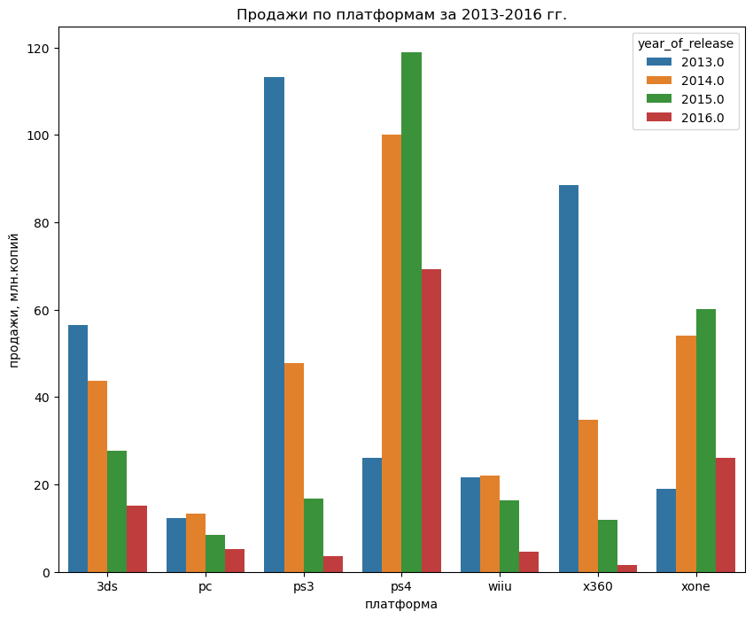

```python
top_new7 = data_new.query('platform in ["ps4","ps3","xone","3ds","x360","wiiu","pc"]').pivot_table(
    index=['platform','year_of_release'],values='total_sales',aggfunc='sum').reset_index()

plt.figure(figsize=(10, 8))
sns.barplot(x="platform", y="total_sales", hue="year_of_release", data=top_new7)

plt.title('Продажи по платформам за 2013-2016 гг.')

plt.xlabel('платформа')
plt.ylabel('продажи, млн.копий')


plt.show()
```

#### Построение графика «ящик с усами» по глобальным продажам игр в разбивке по платформам

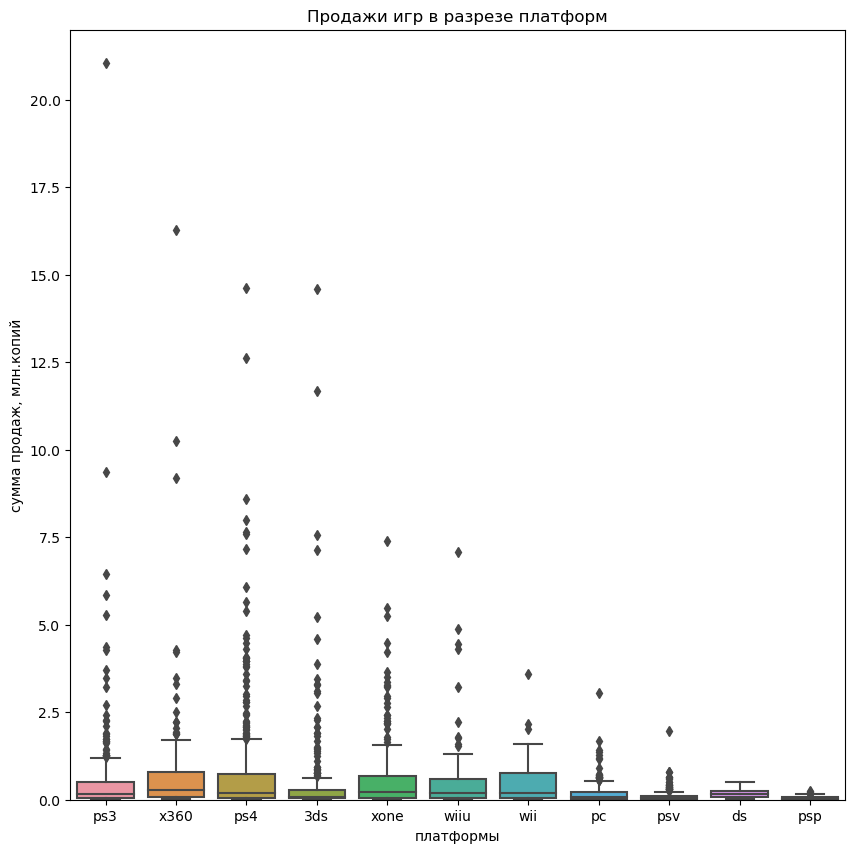

```
count    2233.000000
mean        0.488442
std         1.235226
min         0.010000
25%         0.030000
50%         0.110000
75%         0.400000
max        21.050000
Name: total_sales, dtype: float64
```

```python
plt.figure(figsize=(10, 10))

sns.boxplot(x='platform',y='total_sales',data=data_new)

plt.ylim(0, 22)

plt.title('Продажи игр в разрезе платформ')
plt.xlabel('платформы')
plt.ylabel('сумма продаж, млн.копий')

plt.show()

data_new['total_sales'].describe()
```

Диаграмма размаха в 100% масштабе показывает, что выбросы есть практически по всем платформам, это говорит об отдельных играх, которые "выстрелили". Самые высокие продажи можно отметить по платформе ps3.

Для наглядности добавим второй вид, с другим масштабом по оси y, где будет отображена только нижняя часть boxplot-ов

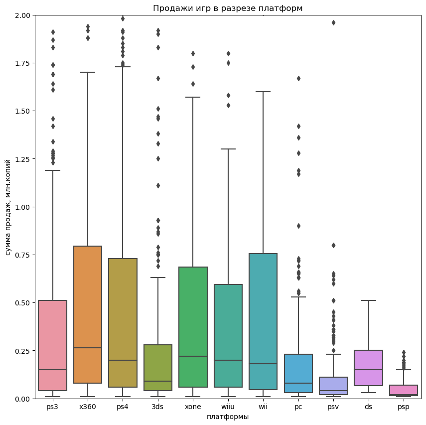

```
count    2233.000000
mean        0.488442
std         1.235226
min         0.010000
25%         0.030000
50%         0.110000
75%         0.400000
max        21.050000
Name: total_sales, dtype: float64
```

```python
plt.figure(figsize=(10, 10))

sns.boxplot(x='platform',y='total_sales',data=data_new)

plt.ylim(0, 2)

plt.title('Продажи игр в разрезе платформ')
plt.xlabel('платформы')
plt.ylabel('сумма продаж, млн.копий')

plt.show()

data_new['total_sales'].describe()
```

#### Влияние отзывов пользователей и критиков на продажи.

Для начала сфомируем диаграмму рассеяния и коэффициент корреляции по платформам и посмотрим на корреляцию оценок критиков и продаж.

```python
# отключим предупреждения

warnings.filterwarnings('ignore', category=RuntimeWarning)
```

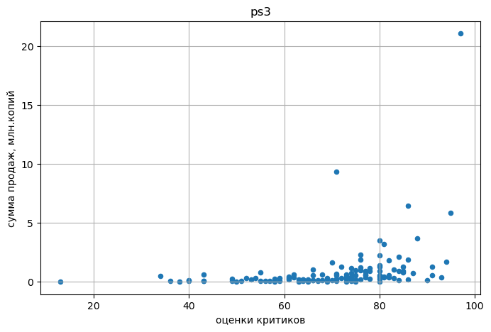

```
0.3342853393371919
```

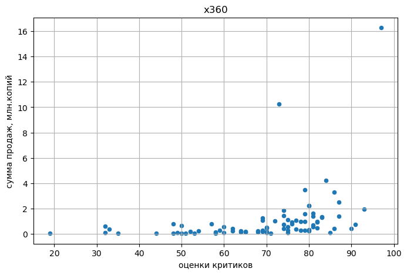

```
0.3503445460228664
```

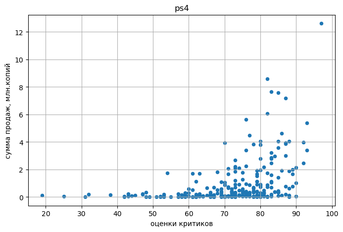

```
0.40656790206178095
```

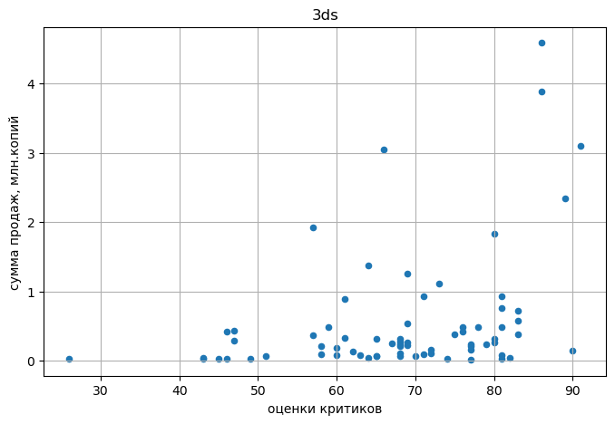

```
0.3570566142288103
```

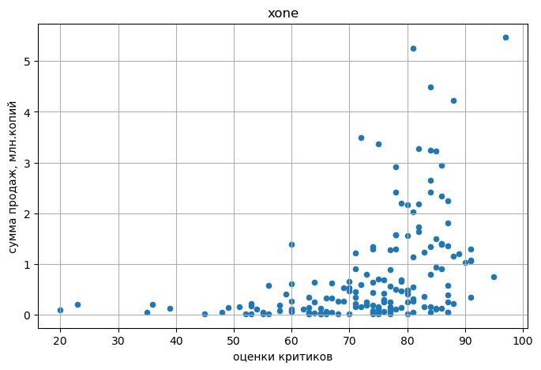

```
0.4169983280084017
```

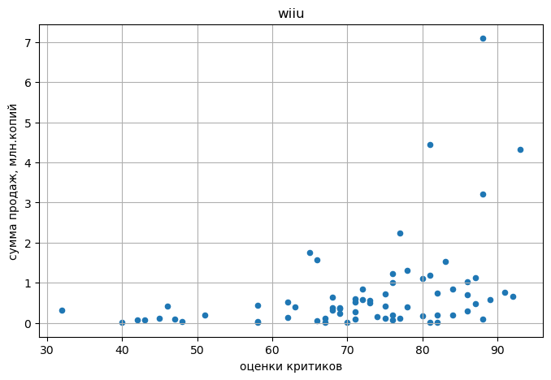

```
0.3764149065423912
```

[figure not shown]

```
nan
```

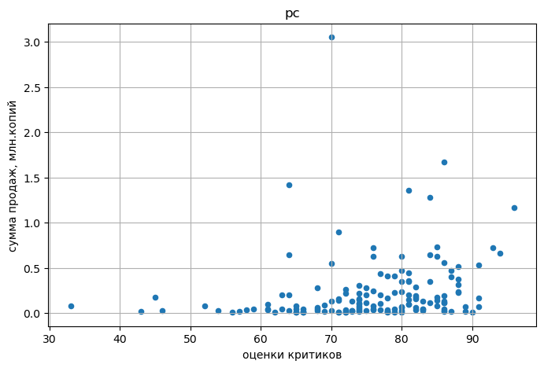

```
0.19603028294369382
```

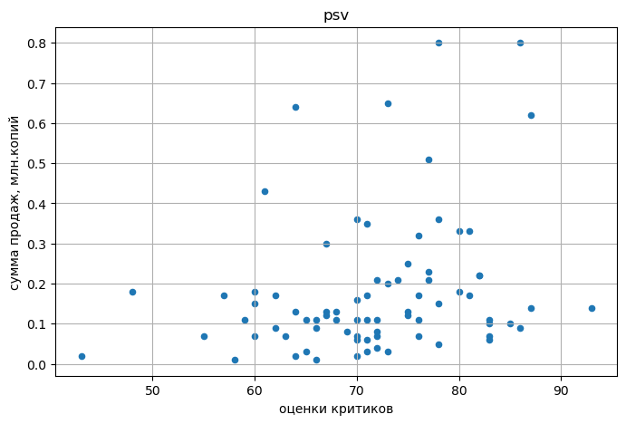

```
0.2547423503068656
```

[figure not shown]

```
nan
```

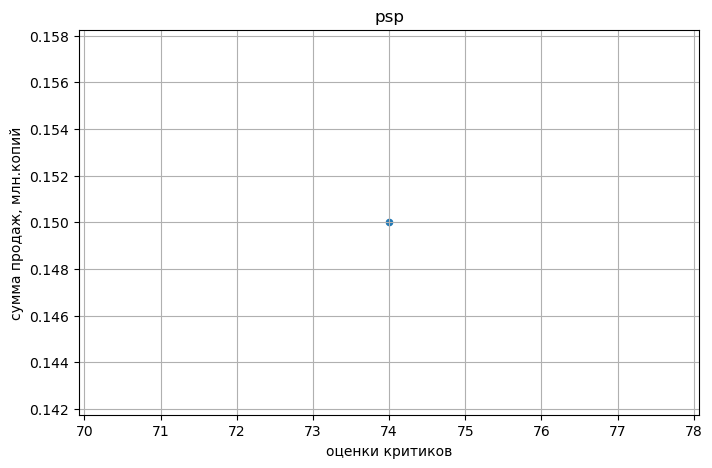

```
nan
```

```python
for i in data_new['platform'].unique():

    data_new.query('platform==@i').plot(
        x='critic_score',y='total_sales',kind='scatter',sharex=False, figsize=(8,5),grid=True,title=i)

    plt.xlabel('оценки критиков')
    plt.ylabel('сумма продаж, млн.копий')

    plt.show()
    print(data_new.query('platform==@i')['critic_score'].corr(data_new.query('platform==@i')['total_sales']))
```

Мы видим, что зависимость есть, хоть и не очень большая. По основным популярным платформам к-т около 0,3-0,4. Зависимость прямая, однако мы не можем с уверенностью сказать, что оценка критиков влияет на продажи или объем продаж на оценку критиков) Для этого требуется провести отдельное исследование.

Теперь посмотрим на корреляцию отзывов пользователей и продаж.

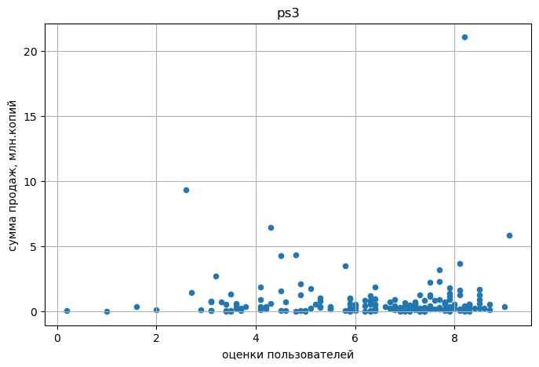

```
0.0023944027357566925
```

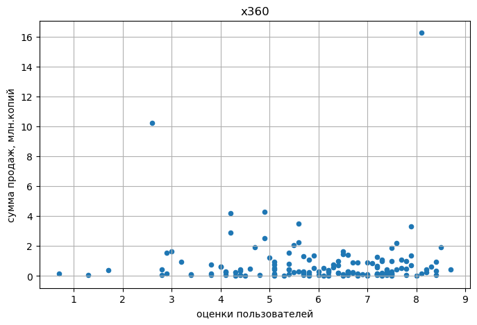

```
-0.011742185147181342
```

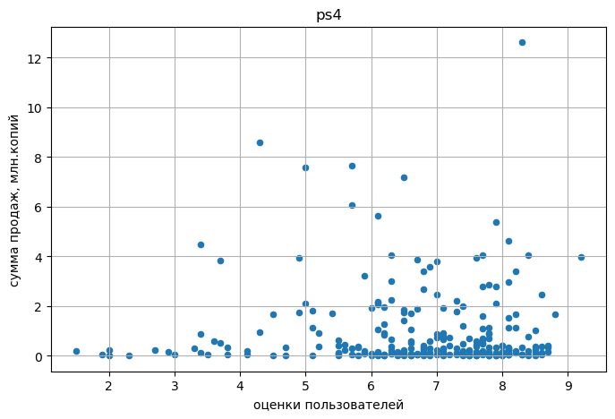

```
-0.031957110204556424
```

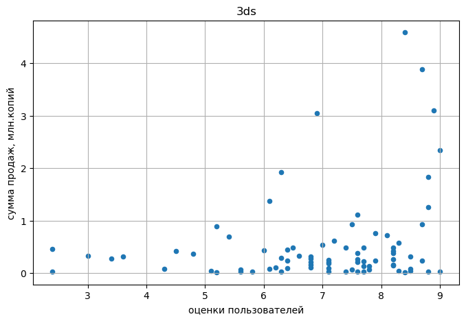

```
0.24150411773563016
```

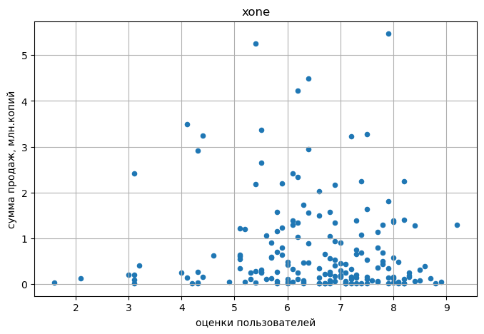

```
-0.06892505328279414
```

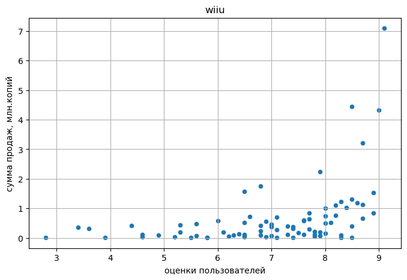

```
0.4193304819266187
```

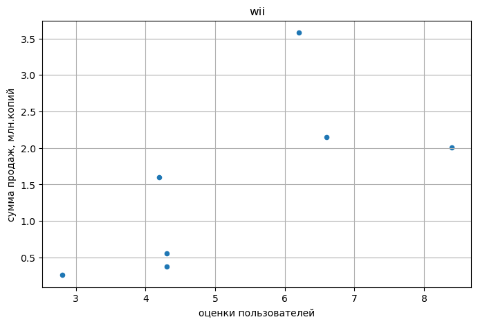

```
0.6829417215362368
```

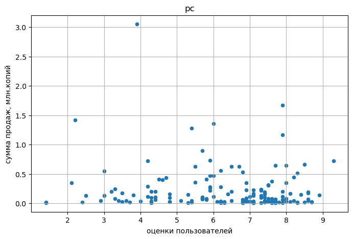

```
-0.0938418695247674
```

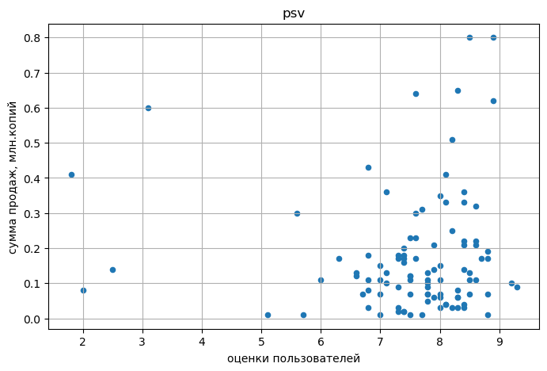

```
0.0009424723319108626
```

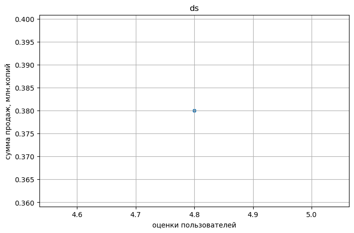

```
nan
```

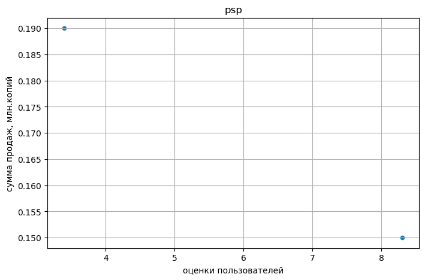

```
-0.9999999999999999
```

```python
for i in data_new['platform'].unique():

    data_new.query('platform==@i').plot(
        x='user_score', y='total_sales',kind='scatter', sharex=False,figsize=(8,5),grid=True,title=i)

    plt.xlabel('оценки пользователей')
    plt.ylabel('сумма продаж, млн.копий')

    plt.show()

    print(data_new.query('platform==@i')['user_score'].corr(data_new.query('platform==@i')['total_sales']))
```

Мы видим, что в основном к-т корреляции находится около 0. Это говорит о том, что корреляции между ними практически нет.

#### Распределение по жанрам. Самые востребованные жанры.

Посмотрим в целом как распределены продажи по жанрам, какие лидируют, а какие не интересны пользователям.

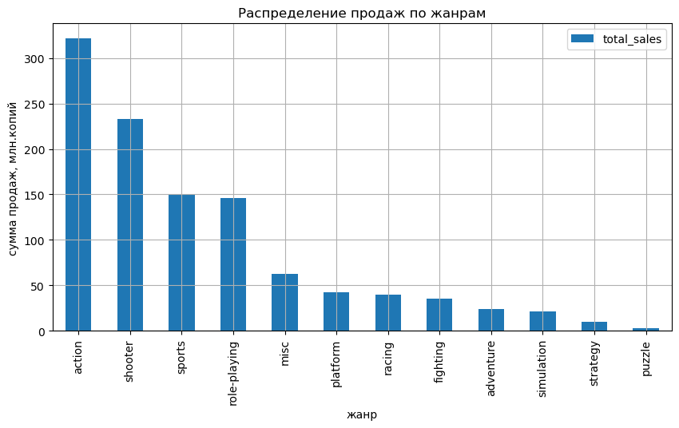

```python
data_new.pivot_table(index='genre',values='total_sales',aggfunc='sum').sort_values(by='total_sales', ascending=False).plot.bar(figsize=(10,5),grid=True)

plt.title('Распределение продаж по жанрам')

plt.xlabel('жанр')
plt.ylabel('сумма продаж, млн.копий')

plt.show()
```

На первый взгляд (по общей сумме продаж) самые популярные жанры - Action и Shooter, наименее популярный - Puzzle.

Построим диаграммы размаха, чтобы детальнее проанализировать прибыльность жанров.

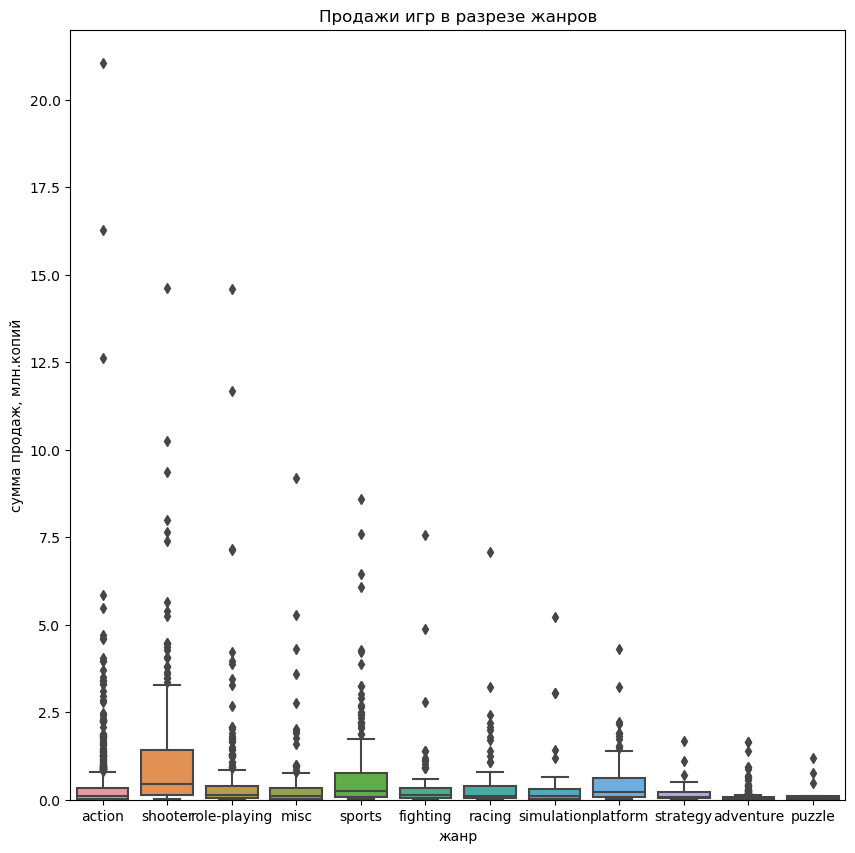

```
count    2233.000000
mean        0.488442
std         1.235226
min         0.010000
25%         0.030000
50%         0.110000
75%         0.400000
max        21.050000
Name: total_sales, dtype: float64
```

```python
plt.figure(figsize=(10, 10))

sns.boxplot(x='genre',y='total_sales',data=data_new)

plt.ylim(0, 22)
#plt.ylim(0, 2) потом изменить масштаб, чтобы посмотреть общую тенденцию

plt.title('Продажи игр в разрезе жанров')
plt.xlabel('жанр')
plt.ylabel('сумма продаж, млн.копий')

plt.show()

data_new['total_sales'].describe()
```

Диаграмма размаха показывает нам, что жанр Action (самый популярный на предыдущем графике) на самом деле вышел на первое место из-за выбросов - отдельных высоких продаж.

Посмотри на график в другом масштабе, исключая выбросы.

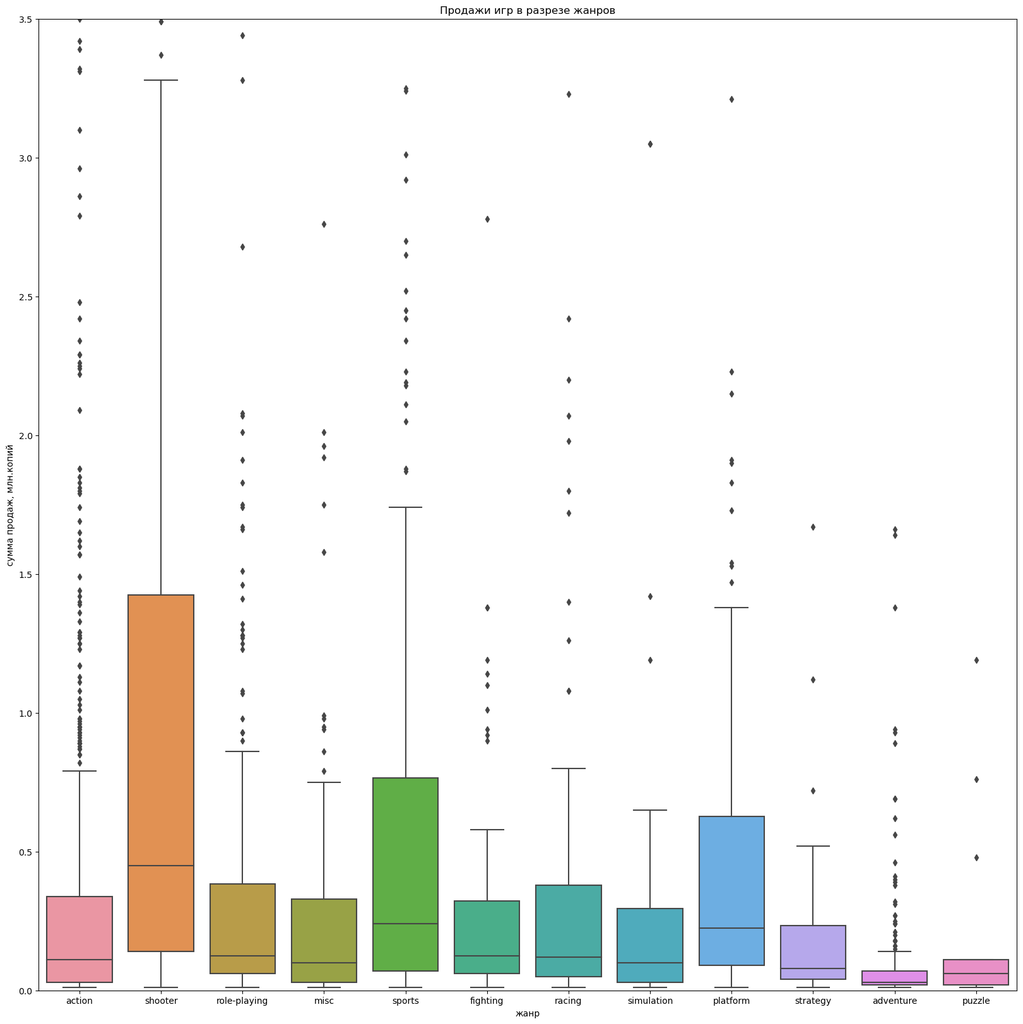

```python
plt.figure(figsize=(20, 20))

sns.boxplot(x='genre',y='total_sales',data=data_new)

plt.ylim(0, 3.5)

plt.title('Продажи игр в разрезе жанров')
plt.xlabel('жанр')
plt.ylabel('сумма продаж, млн.копий')

plt.show()
```

Видно, что по медианным значениям и размаху до 75 квантиля лидируют жанры Shooter, Sports, Platform. То есть эти жанры можно отнести к более стабильным и прибыльным.

**Вывод по разделу 1.3**

Проведя исследоательский анализ данных, можно сделать следующие выводы:

- за историю выпуска игр с 1980 г. до 2016 г. пик выпуска игр приходится на 2008-2009 гг. Активный рост начался после 1994 г. С 2012 г. и до сегодняшнего дня отмечено общее падение спроса, поэтому все прогнозы необходимо делать в новых условиях рынка;
- самые популярные платформы за историю - 'PS2', 'X360','PS3' ,'Wii' ,'DS';
- средний срок жизни платформы - 10 лет;
- актуальный период для составления прогноза на 2017 г. - данные с 2013 г. по 2016 г. При выборе актуального периода учитывались общее падение рынка с 2013 г., а также срок жизни платформы (в среднем 10 лет);
- потенциальные платформы по данным актуального периода - "PS4","PS3","XOne","3DS","X360","Wiiu","PC", при этом стадия роста наблюдается только по 2 платформам - PS4, XOne;
- в разрезе платформ объем средних продаж игр не превышает 0,25 млн.;
- выявлена корреляция оценок критиков и объемов продаж. Коэффициент корреляции в среднем 0,3-0,4; по оценкам пользователей корреляции не выявлено;
- самыми стабильными и популярными жанрами игр являются Shooter, Sports, Platform, а жанр Action выстреливает отдельными крутыми играми и высокими продаж

### Составление портрета пользователя каждого региона

#### Популярные платформы по регионам

В разрезе регионов сформируем топ-5 самых популярных игровых платформ.

```python
data_new.pivot_table(index='platform',values='na_sales',aggfunc='sum').sort_values(
    by='na_sales', ascending=False).head()
```

| platform | na_sales |
| --- | --- |
| ps4 | 108.74 |
| xone | 93.12 |
| x360 | 81.66 |
| ps3 | 63.50 |
| 3ds | 38.20 |

```python
#остальные платформы соберем в группу others

top_platform_na = ['ps4','xone','x360','ps3','3ds']

platform_na = data_new.pivot_table(index='platform',values='na_sales',aggfunc='sum').reset_index()

def platform_na_type(row):

    if row['platform'] in top_platform_na:

        return row['platform']

    return 'others'

platform_na['platform_na_type'] = platform_na.apply(platform_na_type,axis=1)

platform_na = platform_na.pivot_table(
    index='platform_na_type',values='na_sales',aggfunc='sum').sort_values( by='na_sales', ascending=False)

platform_na
```

| platform_na_type | na_sales |
| --- | --- |
| ps4 | 108.74 |
| xone | 93.12 |
| x360 | 81.66 |
| ps3 | 63.50 |
| others | 52.49 |
| 3ds | 38.20 |

То же самое сделаем для двух других регионов.

```python
#для Европы

data_new.pivot_table(index='platform',values='eu_sales',aggfunc='sum').sort_values(
    by='eu_sales', ascending=False).head()
```

| platform | eu_sales |
| --- | --- |
| ps4 | 141.09 |
| ps3 | 67.81 |
| xone | 51.59 |
| x360 | 42.52 |
| 3ds | 30.96 |

```python
top_platform_eu = ['ps4','ps3','xone','x360','3ds']

platform_eu = data_new.pivot_table(index='platform',values='eu_sales',aggfunc='sum').reset_index()

def platform_eu_type(row):

    if row['platform'] in top_platform_eu:

        return row['platform']

    return 'others'

platform_eu['platform_eu_type'] = platform_eu.apply(platform_eu_type,axis=1)

platform_eu = platform_eu.pivot_table(
    index='platform_eu_type',values='eu_sales',aggfunc='sum').sort_values( by='eu_sales', ascending=False)
platform_eu
```

| platform_eu_type | eu_sales |
| --- | --- |
| ps4 | 141.09 |
| ps3 | 67.81 |
| others | 58.26 |
| xone | 51.59 |
| x360 | 42.52 |
| 3ds | 30.96 |

```python
#для Японии

data_new.pivot_table(index='platform',values='jp_sales',aggfunc='sum').sort_values(
    by='jp_sales', ascending=False).head()
```

| platform | jp_sales |
| --- | --- |
| 3ds | 67.81 |
| ps3 | 23.35 |
| psv | 18.59 |
| ps4 | 15.96 |
| wiiu | 10.88 |

```python
top_platform_jp = ['3ds', 'ps3', 'psv','ps4','wiiu']

platform_jp = data_new.pivot_table(index='platform',values='jp_sales',aggfunc='sum').reset_index()

def platform_jp_type(row):

    if row['platform'] in top_platform_jp:

        return row['platform']

    return 'others'

platform_jp['platform_jp_type'] = platform_jp.apply(platform_jp_type,axis=1)

platform_jp = platform_jp.pivot_table(
    index='platform_jp_type',values='jp_sales',aggfunc='sum').sort_values( by='jp_sales', ascending=False)
platform_jp
```

| platform_jp_type | jp_sales |
| --- | --- |
| 3ds | 67.81 |
| ps3 | 23.35 |
| psv | 18.59 |
| ps4 | 15.96 |
| wiiu | 10.88 |
| others | 4.19 |

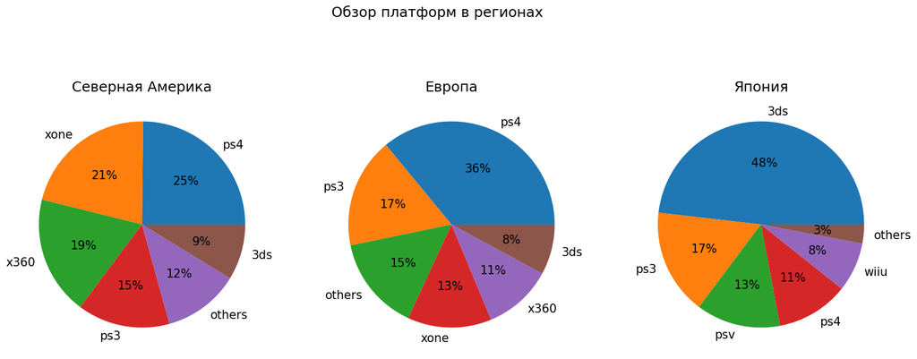

```python
fig, (ax0,ax1,ax2) = plt.subplots(nrows=1,ncols=3,figsize=(20,8))

plt.rc('font', size= 15 )

fig. suptitle('Обзор платформ в регионах')

platform_na.plot(kind='pie',y='na_sales', legend=False, autopct='%.0f%%',title='Северная Америка',ax=ax0)
ax0.set(ylabel='')

platform_eu.plot(kind='pie',y='eu_sales',legend=False, autopct='%.0f%%', title='Европа',ax=ax1)
ax1.set(ylabel='')

platform_jp.plot(kind='pie',y='jp_sales',legend=False, autopct='%.0f%%', title='Япония',ax=ax2)
ax2.set(ylabel='')

plt.show()
```

Самая популярная платформа, можно сказать, в мире - это PS. В Америке и Европе рейтинг по платформам похож, отличие мы можем видеть в Японии. Здесь отмечено, что они поддерживают отечественного производителя, так как американская платформа Xbox не вошла в топ-5, зато в топе другие, мало известные в других странах, платформы производства Японии.

#### Популярные жанры по регионам

Сформируем топ-5 самых популярных жанров по регионам

```python
display(data_new.pivot_table(
    index='genre',values='na_sales',aggfunc='sum').sort_values(
    by='na_sales', ascending=False).head())

display(data_new.pivot_table(
    index='genre',values='eu_sales',aggfunc='sum').sort_values(
    by='eu_sales', ascending=False).head())

data_new.pivot_table(
    index='genre',values='jp_sales',aggfunc='sum').sort_values(
    by='jp_sales', ascending=False).head()
```

| genre | na_sales |
| --- | --- |
| action | 126.05 |
| shooter | 109.74 |
| sports | 65.27 |
| role-playing | 46.40 |
| misc | 27.49 |

| genre | eu_sales |
| --- | --- |
| action | 118.13 |
| shooter | 87.86 |
| sports | 60.52 |
| role-playing | 36.97 |
| racing | 20.19 |

| genre | jp_sales |
| --- | --- |
| role-playing | 51.04 |
| action | 40.49 |
| misc | 9.20 |
| fighting | 7.65 |
| shooter | 6.61 |

Прочие жанры объединим в категорию others также как и с платформами.

```python
top_genre_na = ['action', 'shooter', 'sports','role-playing','misc']

genre_na = data_new.pivot_table(index='genre',values='na_sales',aggfunc='sum').reset_index()

def genre_na_type(row):

    if row['genre'] in top_genre_na:

        return row['genre']

    return 'others'

genre_na['genre_na_type'] = genre_na.apply(genre_na_type,axis=1)

genre_na = genre_na.pivot_table(
    index='genre_na_type',values='na_sales',aggfunc='sum').sort_values( by='na_sales', ascending=False)

genre_na
```

| genre_na_type | na_sales |
| --- | --- |
| action | 126.05 |
| shooter | 109.74 |
| sports | 65.27 |
| others | 62.76 |
| role-playing | 46.40 |
| misc | 27.49 |

```python
#для Европы

top_genre_eu = ['action', 'shooter', 'sports','role-playing','racing']

genre_eu = data_new.pivot_table(index='genre',values='eu_sales',aggfunc='sum').reset_index()

def genre_eu_type(row):

    if row['genre'] in top_genre_eu:

        return row['genre']

    return 'others'

genre_eu['genre_eu_type'] = genre_eu.apply(genre_eu_type,axis=1)

genre_eu = genre_eu.pivot_table(
    index='genre_eu_type',values='eu_sales',aggfunc='sum').sort_values( by='eu_sales', ascending=False)

genre_eu
```

| genre_eu_type | eu_sales |
| --- | --- |
| action | 118.13 |
| shooter | 87.86 |
| others | 68.56 |
| sports | 60.52 |
| role-playing | 36.97 |
| racing | 20.19 |

```python
#для Японии

top_genre_jp = ['role-playing','action', 'misc','fighting','shooter']

genre_jp = data_new.pivot_table(index='genre',values='jp_sales',aggfunc='sum').reset_index()

def genre_jp_type(row):

    if row['genre'] in top_genre_jp:

        return row['genre']

    return 'others'

genre_jp['genre_jp_type'] = genre_jp.apply(genre_jp_type,axis=1)

genre_jp = genre_jp.pivot_table(
    index='genre_jp_type',values='jp_sales',aggfunc='sum').sort_values( by='jp_sales', ascending=False)

genre_jp
```

| genre_jp_type | jp_sales |
| --- | --- |
| role-playing | 51.04 |
| action | 40.49 |
| others | 25.79 |
| misc | 9.20 |
| fighting | 7.65 |
| shooter | 6.61 |

Визуализируем полученные данные.

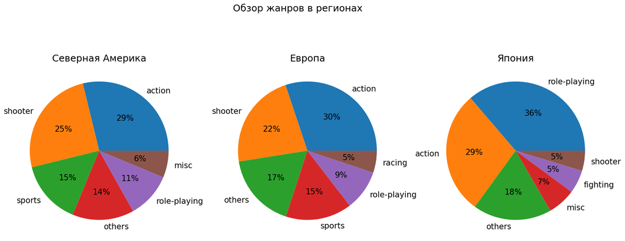

```python
fig, (ax0,ax1,ax2) = plt.subplots(nrows=1,ncols=3,figsize=(20,8))

plt.rc('font', size= 15 )

fig. suptitle('Обзор жанров в регионах')

genre_na.plot(kind='pie',y='na_sales', legend=False, autopct='%.0f%%',title='Северная Америка',ax=ax0)
ax0.set(ylabel='')

genre_eu.plot(kind='pie',y='eu_sales',legend=False, autopct='%.0f%%', title='Европа',ax=ax1)
ax1.set(ylabel='')

genre_jp.plot(kind='pie',y='jp_sales',legend=False, autopct='%.0f%%', title='Япония',ax=ax2)
ax2.set(ylabel='')

plt.show()
```

В Еропе и Северной Америке преобладают жанры Action и Shooter,тогда как в Японии предпочитают role-playing. Это связано с менталитетом стран. Можно сравнить с жанрами фильмов, которые выходят в этих странах, в Северной Америке и Европе преоблядают боевики и экшны, Япония подарила нам аниме. В Японии многое основано на мифологии и философии, именно поэтому более сложные продуманные сюжеты и разносторонние персонажи здесь пользуются большей популярностью.

#### Влияние рейтинга ESRB на продажи в регионах

Посмотрим как влияет рейтинг ESRB на продажи в разных регионах. Для удобства добавим расшифровку наименования рейтинга в отдельный столбец.

```python
# check
data_new.info()
```

```
<class 'pandas.core.frame.DataFrame'>
RangeIndex: 2233 entries, 0 to 2232
Data columns (total 13 columns):
 #   Column           Non-Null Count  Dtype
---  ------           --------------  -----
 0   index            2233 non-null   int64
 1   name             2233 non-null   object
 2   platform         2233 non-null   object
 3   year_of_release  2233 non-null   float64
 4   genre            2233 non-null   object
 5   na_sales         2233 non-null   float64
 6   eu_sales         2233 non-null   float64
 7   jp_sales         2233 non-null   float64
 8   other_sales      2233 non-null   float64
 9   critic_score     991 non-null    float64
 10  user_score       1192 non-null   float64
 11  rating           2233 non-null   object
 12  total_sales      2233 non-null   float64
dtypes: float64(8), int64(1), object(4)
memory usage: 226.9+ KB
```

```python
# вспомним какие в нашей таблице указаны виды рейтинга

data_new['rating'].unique()
```

```
array(['M', 'no_rating', 'E', 'T', 'E10+'], dtype=object)
```

```python
def ESRB_name(row):

    if row['rating'] == "M":
        return '17+'

    if row['rating'] == "E":
        return 'Для всех'

    if row['rating'] == "E10+":
        return '10+'

    if row['rating'] == "T":
        return '13+'

    return 'не указан'

data_new['name_rating'] = data_new.apply(ESRB_name,axis=1)

data_new.head()
```

|  | index | name | platform | year_of_release | genre | na_sales | eu_sales | jp_sales | other_sales | critic_score | user_score | rating | total_sales | name_rating |
| --- | --- | --- | --- | --- | --- | --- | --- | --- | --- | --- | --- | --- | --- | --- |
| 0 | 16 | grand theft auto v | ps3 | 2013.0 | action | 7.02 | 9.09 | 0.98 | 3.96 | 97.0 | 8.2 | M | 21.05 | 17+ |
| 1 | 23 | grand theft auto v | x360 | 2013.0 | action | 9.66 | 5.14 | 0.06 | 1.41 | 97.0 | 8.1 | M | 16.27 | 17+ |
| 2 | 31 | call of duty: black ops 3 | ps4 | 2015.0 | shooter | 6.03 | 5.86 | 0.36 | 2.38 | NaN | NaN | no_rating | 14.63 | не указан |
| 3 | 33 | pokemon x/pokemon y | 3ds | 2013.0 | role-playing | 5.28 | 4.19 | 4.35 | 0.78 | NaN | NaN | no_rating | 14.60 | не указан |
| 4 | 42 | grand theft auto v | ps4 | 2014.0 | action | 3.96 | 6.31 | 0.38 | 1.97 | 97.0 | 8.3 | M | 12.62 | 17+ |

```python
#проверим значения в новом столбце
data_new['name_rating'].value_counts()
```

```
name_rating
не указан    977
17+          369
13+          333
Для всех     302
10+          252
Name: count, dtype: int64
```

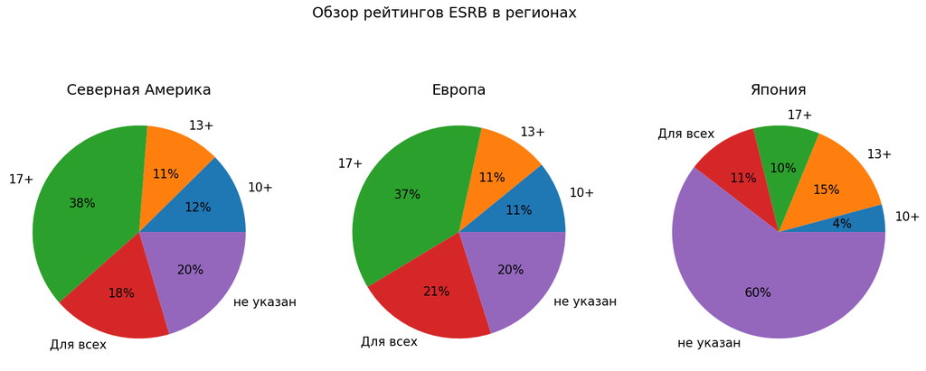

```python
#построим визуализацию

fig, (ax0,ax1,ax2) = plt.subplots(nrows=1,ncols=3,figsize=(20,8))

plt.rc('font', size= 15 )

fig. suptitle('Обзор рейтингов ESRB в регионах')

data_new.pivot_table(index='name_rating',values='na_sales',aggfunc='sum').plot(kind='pie',y='na_sales', legend=False, autopct='%.0f%%',title='Северная Америка',ax=ax0)
ax0.set(ylabel='')

data_new.pivot_table(index='name_rating',values='eu_sales',aggfunc='sum').plot(kind='pie',y='eu_sales',legend=False, autopct='%.0f%%', title='Европа',ax=ax1)
ax1.set(ylabel='')

data_new.pivot_table(index='name_rating',values='jp_sales',aggfunc='sum').plot(kind='pie',y='jp_sales',legend=False, autopct='%.0f%%', title='Япония',ax=ax2)
ax2.set(ylabel='')

plt.show()
```

В СА и Европе больше всего игр продается с рейтингом 17+, это логично, такое ограничение обычно как раз по самым популярным экшн-играм и стрелялкам, популярным в этих регионах. В Японии снова отличие. Во-первых, видно, что у большинства игр не указан рейтинг, а по остальным категориям - наиболее популярны игры с 13+ лет. Это в целом говорит о том, что в данной стране играть начинают намного раньше, и ограничений по возрасту в принципе на компьютерные игры намного меньше.

**Вывод по разделу 1.4**

В данном раздеде мы посмотрели на отличия продаж и специфики пользователей в разных регионах.

Можно сделать вывод, что Северная Америка и Европа - очень похожие регионы.Здесь самыми популряными платформами являются PS и Xbox. Наиболее популярные жанры - Action и Shooter, преобладают игры 17+.

А в Японии мы видим отличие по всем параметрам. Здесь в топе не представлена американская платформа Xbox, зато пользуются популярностью другие японские платформы. Самым популярным жанром в Японии является Role-Playing, а та особенность, что больше всего продаж игр без рейтинга и рейтинга 13+ говорит о том, что в данной стране компьютерными играми увлекаются намного раньше и нет существенных ограничений и запретов.

### Проверка гипотез

В данном разделе проверим несколько гипотез, которые помогут спрогнозировать продажи в 2017 г.

#### Гипотеза 1:

Средние пользовательские рейтинги платформ Xbox One и PC одинаковые.

Сформулируем двустороннюю гипотезу. Нулевая гипотеза - средние пользовательские рейтинги платформ Xbox One и PC равны, альтернативная гипотеза - средние пользовательские рейтинги платформ Xbox One и PC отличаются.

```python
# создадим новые выборки для работы с гипотезами

data_user_score = data_new.query('user_score>=0') #датафрейм без пропусков

хbox_user_score = data_user_score.query('platform=="xone"')['user_score']

pc_user_score = data_user_score.query('platform=="pc"')['user_score']
```

```python
alpha = 0.05

results = st.ttest_ind(хbox_user_score,pc_user_score,equal_var=False)

print('p-значение:', results.pvalue)

if results.pvalue < alpha:
    print('Отвергаем нулевую гипотезу')
else:
    print('Не получилось отвергнуть нулевую гипотезу')
```

```
p-значение: 0.14759594013430463
Не получилось отвергнуть нулевую гипотезу
```

Таким образом, мы не можем откинуть гипотезу о том, что средние рейтинги по оценкам пользователей на платформах XOne и PC одинаковы.

#### Гипотеза 2:

Средние пользовательские рейтинги жанров Action (англ. «действие», экшен-игры) и Sports (англ. «спортивные соревнования») разные.

Сформулируем двустороннюю гипотезу. Нулевая гипотеза - средние пользовательские рейтинги жанров Action и Sports равны, альтернативная гипотеза - средние пользовательские рейтинги жанров Action и Sports отличаются.

```python
action_user_score = data_user_score.query('genre=="action"')['user_score']
sports_user_score = data_user_score.query('genre=="sports"')['user_score']

alpha = 0.05

results = st.ttest_ind(action_user_score,sports_user_score,equal_var=False)

print('p-значение:', results.pvalue)

if results.pvalue < alpha:
    print('Отвергаем нулевую гипотезу')
else:
    print('Не получилось отвергнуть нулевую гипотезу')
```

```
p-значение: 1.4460039700704315e-20
Отвергаем нулевую гипотезу
```

```python
#посмотрм у какого жанра рейтинг выше

print(action_user_score.mean())

sports_user_score.mean()
```

```
6.837532133676092
```

```
5.238124999999999
```

Средние пользовательские рейтинги жанров Action и Sports отличаются, рейтинг по играм жанра Action выше.

**Вывод по разделу 1.5**

Для составления прогноза на 2017 г. были сформулированы и проверены 2 гипотезы:

- Средние пользовательские рейтинги платформ Xbox One и PC одинаковые - **Не можем отвергнуть данную гипотезу**
- Средние пользовательские рейтинги жанров Action и Sports разные - **Гипотеза подтвердилась.**

### Общий вывод

**Цель данного проекта** – провести исследовательский анализ данных и определить закономерности, влияющие на успешность продажи игр для планирования рекламных кампании.

**Входные данные**— данные из открытых источников с 1980 г. до 2016 г., информация содержит данные о продажах компьютерных игр, оценках пользователей и критиков, жанрах и платформах). За 2016 г. предоставлены неполные данные.

Была проведена предобработка данных:

1. переименованы столбцы и значения в категориальных колонках (наименования приведены к нижнему регистру);
2. изменен тип данных в одном столбце (user_score);
3. пропусков в исходных данных было достаточно большое количество по разным столбцам. Пропуски максимально обработаны - удалены строки, в которых отсутствовала ключевая информация для дальнейшего исследования, но это не критичное количество и составило только 1,6%, пропуски в оценках критиков и пользователей оставлены без изменений, чтобы не исказить общую картину;
4. отработаны дубликаты. Полных дубликатов нет, неполные дубликаты устранены, неявные дубликаты выявлены только в столбце rating, были заменены;
5. также добавлен дополнительный столбец total_sales с общей суммой продаж по всем регионам.

По результатам исследовательского анализа сделаны следующие выводы:

- за историю выпуска игр с 1980 г. до 2016 г. пик выпуска игр приходится на 2008-2009 гг. Активный рост начался после 1994 г. С 2012 г. и до сегодняшнего дня отмечено общее падение спроса, поэтому все прогнозы необходимо делать в новых условиях рынка;
- самые популярные платформы за историю 'PS2', 'X360','PS3' ,'Wii' ,'DS';
- средний срок жизни платформы - 10 лет.

**Выявлены особенности, закономерности, которые будут полезны при формировании прогноза на 2017 г.:**

1. актуальный период для составления прогноза на 2017 г. - данные с 2013 г. по 2016 г.;
2. потенциальные платформы по данным актуального периода - "PS4","XOne","3DS",при этом стадия роста наблюдается по 2 платформам - PS4, XOne. Также не стоит откидывать РС и Wiiu при прогнозе, занимающие определенные ниши;
3. объем средних продаж игр не превышает 0,25 млн.;
4. отмечена зависимость между оценками критиков и объемами продаж, но это требует отдельного исследования, нет корреляции между оценками пользователей и продажами;
5. самыми стабильными и популярными жанрами игр являются Shooter, Sports, Platform, а жанр Action выстреливает отдельными крутыми играми и высокими продажами.

Также был проведен анализ в разрезе регионов продаж.

По результатам анализа можно сделать вывод, что Северная Америка и Европа - очень похожие регионы. Здесь самыми популярными платформами являются PS и Xbox. Наиболее популярные жанры - Action и Shooter, преобладают игры 17+. Продажи в Японии существенно отличаются. Здесь в топе не представлена американская платформа Xbox, зато пользуются популярностью другие японские платформы. Самым популярным жанром в Японии является Role-Playing, а та особенность, что больше всего продаж игр без рейтинга и рейтинга 13+ говорит о том, что в данной стране компьютерными играми увлекаются намного раньше и нет существенных ограничений и запретов.

В процессе дальнейшего анализа проверялись 2 гипотезы:

1. Средние пользовательские рейтинги платформ Xbox One и PC одинаковые;
2. Средние пользовательские рейтинги жанров Action и Sports разные.

Получены следующие результаты:

1. **Гипотеза №1 не может быть отвергнута.**
2. **Гипотеза №2 подтвердилась.**